# Entrega P4

*7.5.1. Descriptor gráfico:*

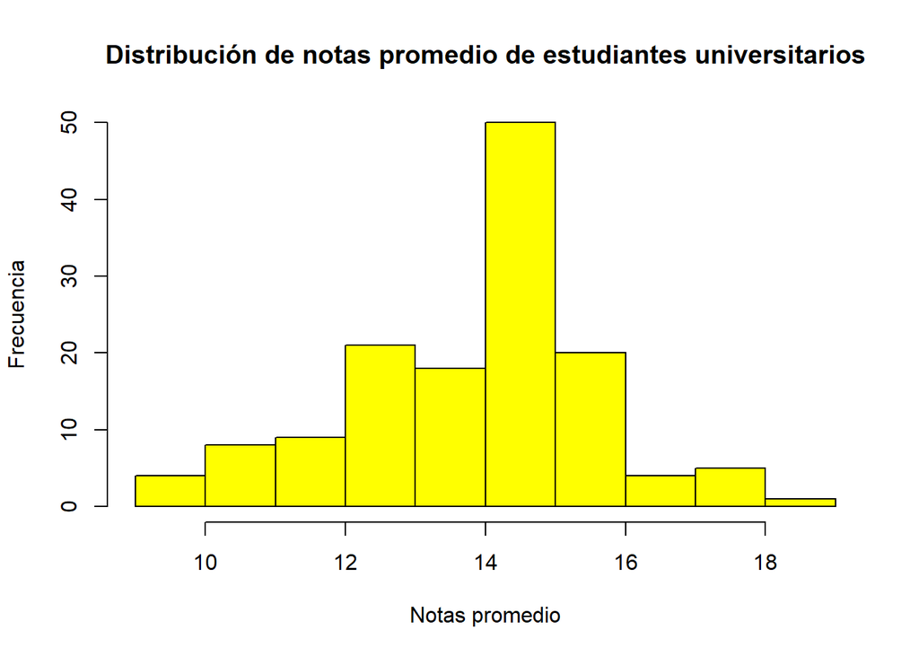

```r
hist(DFV$Promedio_academico,col="yellow", main="Distribución de notas promedio de estudiantes universitarios",xlab="Notas promedio", ylab="Frecuencia")
```

*7.5.2. Análisis del gráfico:*

En el histograma “Distribución de notas promedio de estudiantes universitarios” se puede visualizar la distribución asimétrica en cuanto a la frecuencia de las notas promedio de los estudiantes encuestados, siendo ligeramente asimétrica hacia la izquierda. Además de ello, es válido decir el valor de la moda en el estudio de esta variable, el cual oscila entre 14 y 15 de nota como promedio.

*7.5.3. Quinta hipótesis:*

La nota promedio de los estudiantes equivalente a 13. Esto es un valor referencial puesto que en mucha instituciones de calidad se exige a los alumnos que la nota mínima para aprobar es 13.

**7.6. Sexta pregunta** **¿La cantidad de dispositivos tecnológicos influye en el promedio académico de los estudiantes?**

*7.6.1. Descriptor gráfico:*

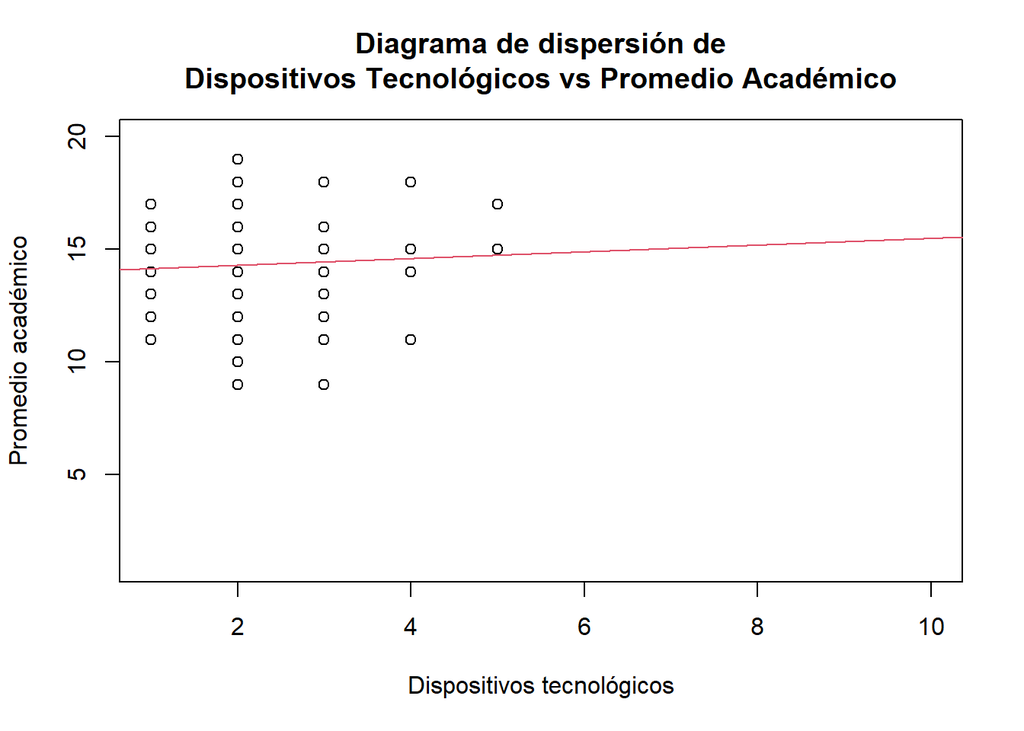

```r
plot(DFV$Dispositivos_tecnologicos,DFV$Promedio_academico, main = "Diagrama de dispersión de
Dispositivos Tecnológicos vs Promedio Académico",xlab = "Dispositivos tecnológicos",ylab = "Promedio académico", xlim=c(1,10), ylim=c(1,20))
abline(lm(DFV$Promedio_academico~DFV$Dispositivos_tecnologicos), col=2)  # regresion line
```

```r
table(DFV[DFV$Soy == "Universitario",]$Dispositivos_tecnologicos,DFV[DFV$Soy == "Universitario",]$Promedio_academico)
```

```
##
##      9 10 11 12 13 14 15 16 17 18 19
##   1  0  0  1  1  2  2  9  2  1  0  0
##   2  1  1  4  6 16 13 31 14  2  1  1
##   3  2  0  2  2  3  1  7  4  0  1  0
##   4  0  0  1  0  0  2  2  0  0  3  0
##   5  0  0  0  0  0  0  1  0  1  0  0
```

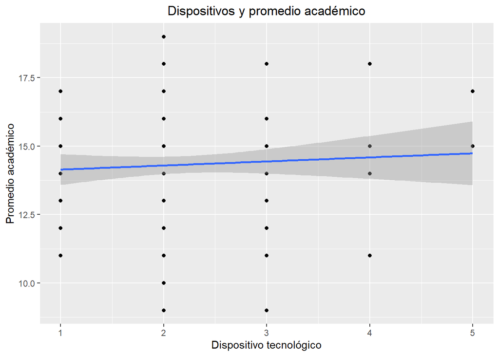

```r
ggplot(DFV, aes(x=Dispositivos_tecnologicos, y=Promedio_academico)) + geom_point()+ stat_smooth(method=lm) +ggtitle("Dispositivos y promedio académico")+theme(plot.title = element_text(hjust = 0.5)) + xlab("Dispositivo tecnológico") + ylab("Promedio académico")
```

*7.6.2. Análisis del gráfico:*

Analizando nuestros diagramas de dispersión podemos observar que la cantidad de dispositivos tecnológicos que tiene un estudiante no influye mucho en el promedio académico que este posee. De los encuestados, el 64.29% tiene solamente 2 dispositivos y sus notas varían entre 9 y 19 de promedio, lo cual es un indicador de que en realidad la cantidad de dispositivos, si bien es una ventaja tener más de uno, no te ayudan a sacar un mejor promedio. Además, así como tenemos casos en donde con 2 dispositivos hay altas calificaciones, tenemos observaciones que indican que hasta con 4 dispositivos el promedio puede ser 11, y que con un solo dispositivo tu promedio puede ser 17. Otro indicador es que en el diagrama podemos ver que la pendiente de la regresión lineal es casi horizontal, lo que significa que no hay una relación fuerte entre las 2 variables.

*7.6.3. Sexta hipótesis:*

Probablemente más del 50 % de los estudiantes encuestados, haga uso de 2 dispositivos tecnológicos y sus notas varíen entre 9 y 11 de promedio. Así como también, hayan casos, en donde, haciendo uso de la misma cantidad de dispositivos, el rendimiento de los estudiantes sea destacado. Siendo esto, un indicador que alude a que la cantidad de dispositivos tecnológicos no influye ni positiva ni negativamente en el promedio.

**7.7. Séptima pregunta:** **¿El uso de técnicas de aprendizaje influye en el promedio académico del estudiante?**

*7.7.1. Descriptor gráfico*

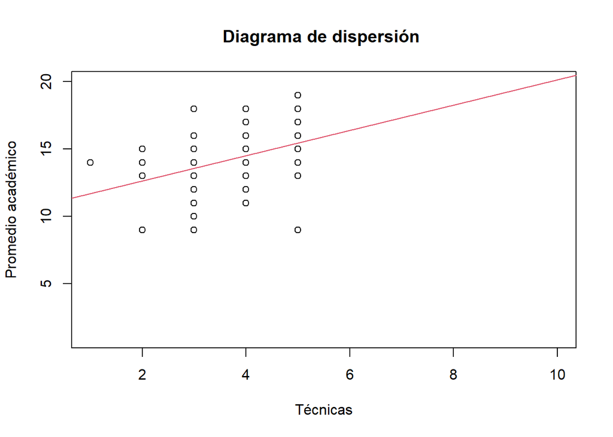

```r
plot(DFV$Cantidad_tecnicas,DFV$Promedio_academico, main = "Diagrama de dispersión ",xlab = "Técnicas",ylab = "Promedio académico", xlim=c(1,10), ylim=c(1,20))
abline(lm(DFV$Promedio_academico~DFV$Cantidad_tecnicas), col=2)  # regresión line
```

```r
table(DFV[DFV$Soy == "Universitario",]$Cantidad_tecnicas,DFV[DFV$Soy == "Universitario",]$Promedio_academico)
```

```
##
##      9 10 11 12 13 14 15 16 17 18 19
##   1  0  0  0  0  0  1  0  0  0  0  0
##   2  1  0  0  0  1  1  1  0  0  0  0
##   3  1  1  6  7  3  6 13  4  0  1  0
##   4  0  0  2  2 15  9 32  6  1  1  0
##   5  1  0  0  0  2  1  4 10  3  3  1
```

*7.7.2. Análisis del gráfico:*

*7.7.3. Séptima hipótesis:*

La cantidad de técnicas de dinamismo en clase influye de manera directa y fuerte en los promedios académicos de los estudiantes.

**7.8. Octava pregunta:** **¿El uso de herramientas de comunicación influye en el promedio académico de los estudiantes?**

*7.8.1. Descriptor gráfico:*

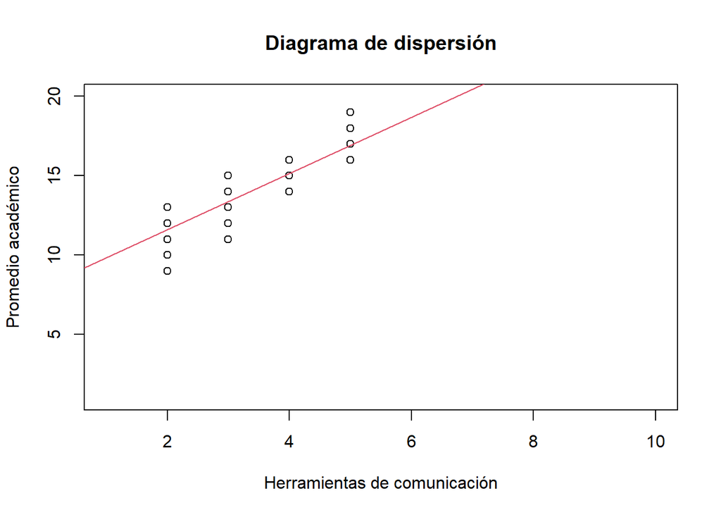

```r
plot(DFV$Cantidad_herramientas,DFV$Promedio_academico, main = "Diagrama de dispersión",xlab = "Herramientas de comunicación",ylab = "Promedio académico", xlim=c(1,10), ylim=c(1,20))
abline(lm(DFV$Promedio_academico~DFV$Cantidad_herramientas), col=2)  # regresion line
```

```r
table(DFV[DFV$Soy == "Universitario",]$Cantidad_herramientas,DFV[DFV$Soy == "Universitario",]$Promedio_academico)
```

```
##
##      9 10 11 12 13 14 15 16 17 18 19
##   2  3  1  7  3  1  0  0  0  0  0  0
##   3  0  0  1  6 20 13 18  0  0  0  0
##   4  0  0  0  0  0  5 32  8  0  0  0
##   5  0  0  0  0  0  0  0 12  4  5  1
```

*7.8.2. Análisis del gráfico:*

*7.8.3. Octava hipótesis:* Los indicadores nos demuestran que a medida que los estudiantes tienen más maneras de comunicarse con sus maestros, su promedio académico es mayor.

**7.9. Novena pregunta:** **¿Cuál es el promedio con mayor frecuencia en los estudiantes encuestados?**

*7.9.1. Descriptor numérico:*

```r
temp1 <- DFV[!is.na(DFV$`Promedio_academico`), ]
cat("El promedio con mayor frecuencia es: ", mode(temp1$Promedio_academico))
```

```
## El promedio con mayor frecuencia es:  numeric
```

*7.9.2. Descriptor gráfico:*

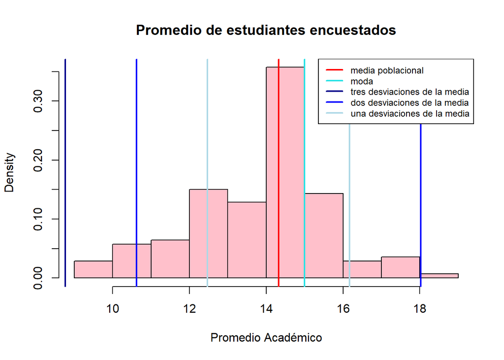

```
## [1] 14.32143
```

```
## [1] "15"
```

```
## [1] 15
```

*7.9.3. Análisis del histograma:*

En el siguiente gráfico “Promedio de estudiantes encuestados”, se observa que la media del conjunto de datos de la variable es 14.32. Asimismo, de acuerdo con la gráfica podemos observar que gran parte de universitarios tienen notas entre 14 y 15.

*7.9.4. Novena hipótesis:*

El promedio con mayor frecuencia entre las observaciones de la muestra es de 14 y 15, la media de los promedios entre los encuestados es de 14.33, mientras que la mediana y la moda es de 15 para ambos casos. Entre las notas más altas podemos encontrar un 19 y en las más bajas un 9.

**7.10. Décima pregunta:** **¿Cual es la mínima cantidad de dispositivos tecnológicos que hace uso un estudiante universitario para llevar a cabo sus clases en línea?**

*7.10.1. Descriptor numérico*

```r
temp1 <- DFV[!is.na(DFV$`Dispositivos_tecnologicos`), ]
cat("Mínima cantidad de dispositivos: ", min(temp1$Dispositivos_tecnologicos))
```

```
## Mínima cantidad de dispositivos:  1
```

*7.10.2. Descriptor gráfico*

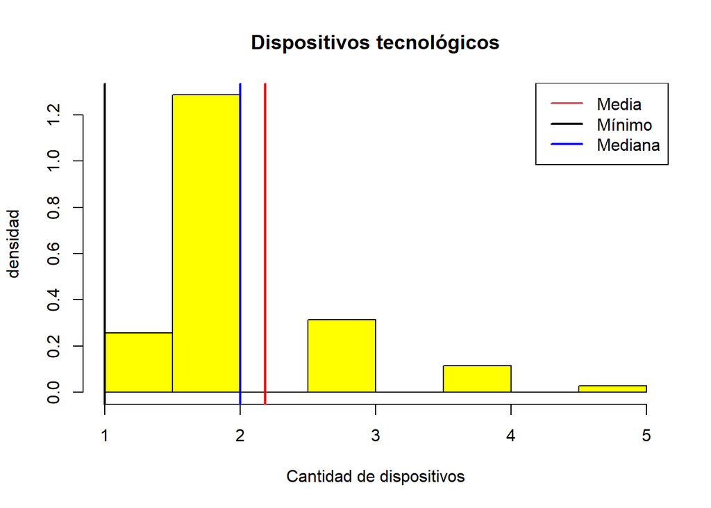

```r
hist(DFV$Dispositivos_tecnologicos,col="yellow",main="Dispositivos tecnológicos",xlab="Cantidad de dispositivos",ylab="densidad",prob=TRUE)
abline(v=mean(DFV$Dispositivos_tecnologicos, na.rm=T),col="red",lwd=2)
abline(v=min(DFV$Dispositivos_tecnologicos, na.rm=T),col="9",lwd=2)
abline(v=median(DFV$Dispositivos_tecnologicos, na.rm=T),col="blue",lwd=2)
legend(x = "topright", legend = c("Media","Mínimo", "Mediana"), lty= c(1,1,1), col=c(2,9,"blue"), lwd=2) # topright es la ubicación de la leyenda
```

*7.10.3. Análisis del histograma:*

Según el histograma “Dispositivos tecnológicos”, se puede observar que la mínima cantidad de dispositivos que tienen los estudiantes universitarios es de una unidad. Asimismo, se observa que la media se aproxima a la mediana, lo que quiere decir que en promedio la mayoría de estudiantes universitarios tienen 2 dispositivos tecnológicos.

*7.10.4. Décima hipótesis:*

*Bloque docente*

**7.11. Pregunta 11:** **¿Cuál es la media del tiempo de enseñanza que tienen los docentes encuestados y como esta tiene relación con la cantidad promedio de horas académicas llevadas en cursos relacionados a las técnicas didácticas de aprendizaje?**

*7.11.1. Descriptor numérico*

```r
temp1 <- DFV[!is.na(DFV$`Tiempo_enseñanza`), ]
temp2 <- DFV[!is.na(DFV$`Horas_curso_docente`), ]
tiempo_ensenado <- temp1$`Tiempo_enseñanza`
tiempo_tecnicas <- temp2$`Horas_curso_docente`
cat("Media para el tiempo enseñado:", round(mean(tiempo_ensenado), digits = 2), "\n")
```

```
## Media para el tiempo enseñado: 13
```

```r
cat("Media para el tiempo tomado en técnicas didácticas:", round(mean(tiempo_tecnicas), digits = 2), "\n")
```

```
## Media para el tiempo tomado en técnicas didácticas: 53.95
```

```r
cat("Correlación: ", round(cor(tiempo_ensenado, tiempo_tecnicas), digits = 2))
```

```
## Correlación:  0.24
```

En cuanto a la correlación, observamos una correlación positiva débil, en donde si una variable aumenta, la otra tiende a aumentar de manera débil.

*7.11.2. Descriptor gráfico*

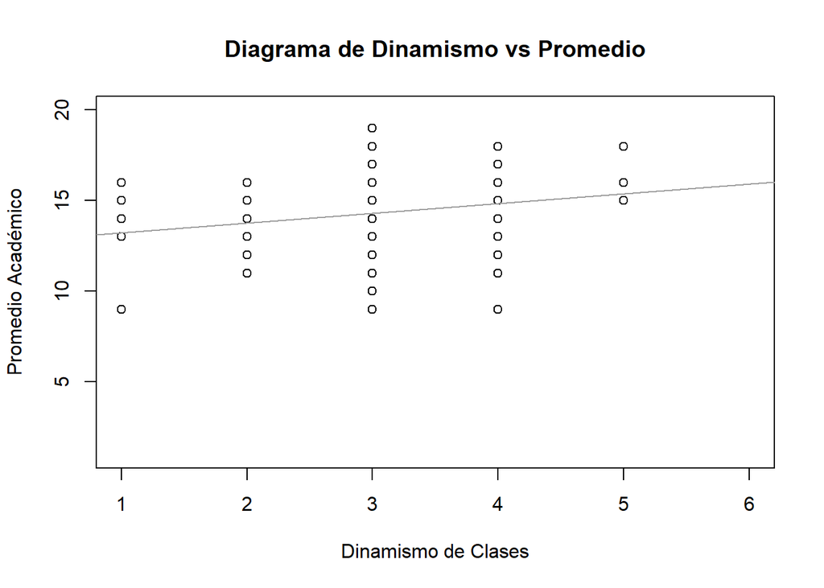

```r
plot(DFV$Dinamismo_clases,DFV$Promedio_academico, main = "Diagrama de Dinamismo vs Promedio",xlab = "Dinamismo de Clases",ylab = "Promedio Académico", xlim=c(1,6), ylim=c(1,20))
abline(lm(DFV$Promedio_academico~DFV$Dinamismo_clases), col=8)  # regresion line
```

```r
table(DFV[DFV$Soy == "Universitario",]$Dinamismo_clases,DFV[DFV$Soy == "Universitario",]$Promedio_academico)
```

```
##
##      9 10 11 12 13 14 15 16 17 18 19
##   1  1  0  0  0  2  1  2  1  0  0  0
##   2  0  0  3  2  6  5 12  1  0  0  0
##   3  1  1  4  4 10  9 17 11  1  1  1
##   4  1  0  1  3  3  3 17  6  3  2  0
##   5  0  0  0  0  0  0  2  1  0  2  0
```

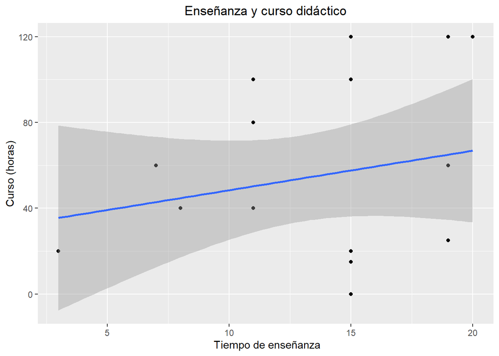

```r
ggplot(DFV, aes(x=Tiempo_enseñanza, y=Horas_curso_docente)) + geom_point()+ stat_smooth(method=lm) + ggtitle("Enseñanza y curso didáctico")+theme(plot.title = element_text(hjust = 0.5)) + xlab(" Tiempo de enseñanza") + ylab("Curso (horas)")
```

*7.11.3. Análisis del gráfico:*

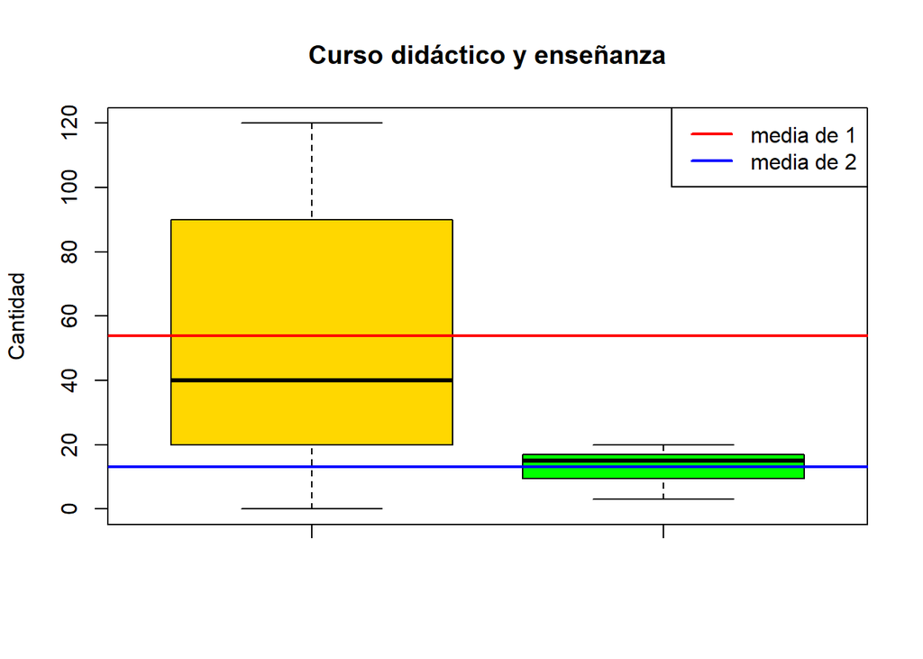

```r
boxplot(DFV$Horas_curso_docente,DFV$Tiempo_enseñanza, col=(c("gold", "green")), ylab="Cantidad", main="Curso didáctico y enseñanza")
abline(h=mean(DFV$Horas_curso_docente, na.rm=T), col="red",lwd=2)
abline(h=mean(DFV$Tiempo_enseñanza, na.rm=T), col="blue",lwd=2)
legend(x = "topright",legend=c("media de 1", "media de 2"),col=c("red", "blue"),lwd=2)
```

*7.11.4. Hipótesis 11:*

Puede un docente con pocos años de docencia haber llevado muchas más horas de cursos didácticos que un profesor que lleva más de una década enseñando.

**7.12. Pregunta 12:** **¿Qué relación guarda la cantidad de horas de competencias digitales que tiene mayor frecuencia con la media de horas de cursos relacionados con las técnicas didácticas de aprendizaje, ambas tomadas por los docentes?**

*7.12.1. Descriptor numérico*

```r
mode <- function(v) {
   uniqv <- unique(v)
   uniqv[which.max(tabulate(match(v, uniqv)))]
}
temp1 <- DFV[!is.na(DFV$`Horas_curso_docente`), ]
temp2 <- DFV[!is.na(DFV$`Horas_competencias_digitales`), ]
tiempo_tecnicas <- temp1$`Horas_curso_docente`
tiempo_competencias <- temp2$`Horas_competencias_digitales`
moda_competencia <- mode(tiempo_competencias)
media_tecnicas <- mean(tiempo_tecnicas)
cat("Moda de las horas de competencias digitales: ", round(moda_competencia,2), "\n")
```

```
## Moda de las horas de competencias digitales:  120
```

```r
cat("Media de las horas de tecnicas didácticas: ", round(media_tecnicas,2), "\n")
```

```
## Media de las horas de tecnicas didácticas:  53.95
```

```r
cat("Correlación entre las variables: ", round(cor(tiempo_tecnicas, tiempo_competencias),2), "\n")
```

```
## Correlación entre las variables:  -0.26
```

*7.12.2. Análisis del gráfico:*

Al observar la correlación entre las 2 variables, tenemos que tienen una correlación negativa débil.

*7.12.3. Descriptor gráfico*

[figure not shown]

```r
plot(DFV$Horas_competencias_digitales,DFV$Horas_curso_docente, main = "Horas de Cursos de Competencias digitales
vs Horas de Cursos de Técnicas Didácticas de Aprendizaje",xlab = "Técnicas Didácticas de Aprendizaje (horas)",ylab = "Competencias digitales (horas)", xlim=c(1,500), ylim=c(1,150))
abline(lm(DFV$Horas_curso_docente~DFV$Horas_competencias_digitales), col=7)  # regresion line
```

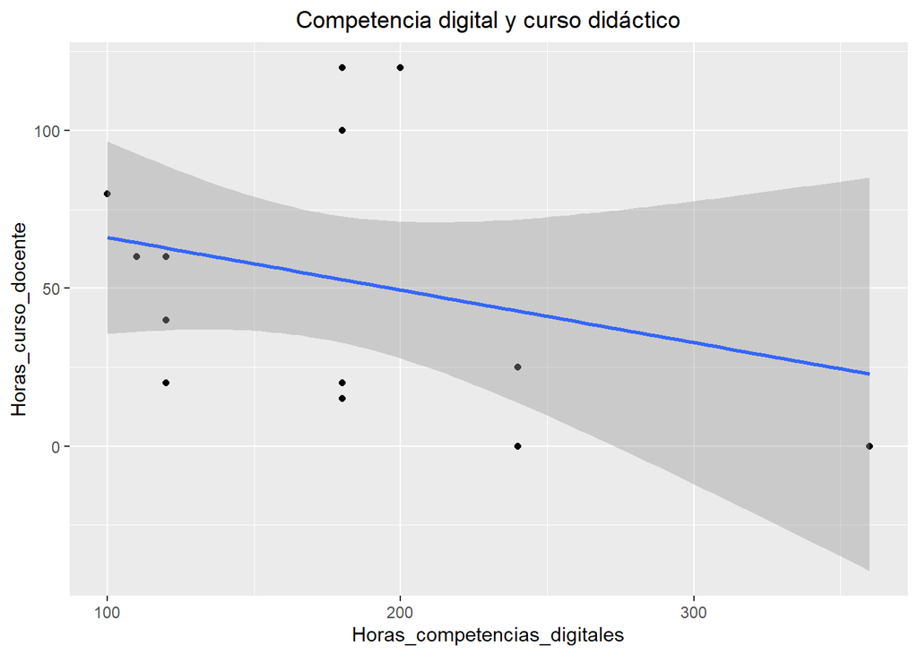

```r
ggplot(DFV, aes(x=Horas_competencias_digitales, y=Horas_curso_docente)) + geom_point()+ stat_smooth(method=lm) +ggtitle("Competencia digital y curso didáctico")+theme(plot.title = element_text(hjust = 0.5))
```

*7.12.4. Análisis:*

Esta relación es únicamente entre variables de maestros, en estas gráficas comparamos las Horas de Cursos de Competencias digitales con las Horas de Cursos de Técnicas Didácticas de Aprendizaje. Según lo reflejado en los gráficos de dispersión podemos observar que no existe mucha relación entre estas 2 variables,ya que la pendiente de la regresión lineal es negativa y de hecho es casi horizontal, y que si en raros casos se relacionan, la tendencia de estas variables, alude a que el valor de la variable “Técnicas didácticas de aprendizaje” disminuye ligeramente a medida que aumenta el valor de la variable “Competencias digitales”.

*7.12.5. Hipótesis 12:*

Las horas de competencias digitales llevadas por los docentes no guarda una relación con la cantidad de cursos llevados de herramientas digitales.

*Bloque estudiantes y los docentes*

**7.13.Pregunta 13:** **¿Qué porcentaje del total de las observaciones recolectadas ocupa la cantidad de estudiantes y docentes encuestados?**

*7.13.1. Descriptor numérico*

```r
temp1 <- DFV[!is.na(DFV$`Soy`), ]
table(temp1$`Soy`)
```

```
##
##       Docente Universitario
##            19           140
```

```r
totDocentes <- length(subset(temp1, temp1$`Soy` == "Docente")$`Soy`)
totUniversitario <- length(subset(temp1, temp1$`Soy` == "Universitario")$`Soy`)
total <- totDocentes+totUniversitario
p_docentes <- totDocentes*100/total
p_universitarios <- totUniversitario*100/total
cat("El porcentaje de docentes es: ", round(p_docentes,2), "%\n")
```

```
## El porcentaje de docentes es:  11.95 %
```

```r
cat("El porcentaje de Universitarios es: ", round(p_universitarios,2), "%")
```

```
## El porcentaje de Universitarios es:  88.05 %
```

*7.13.2. Descriptor gráfico*

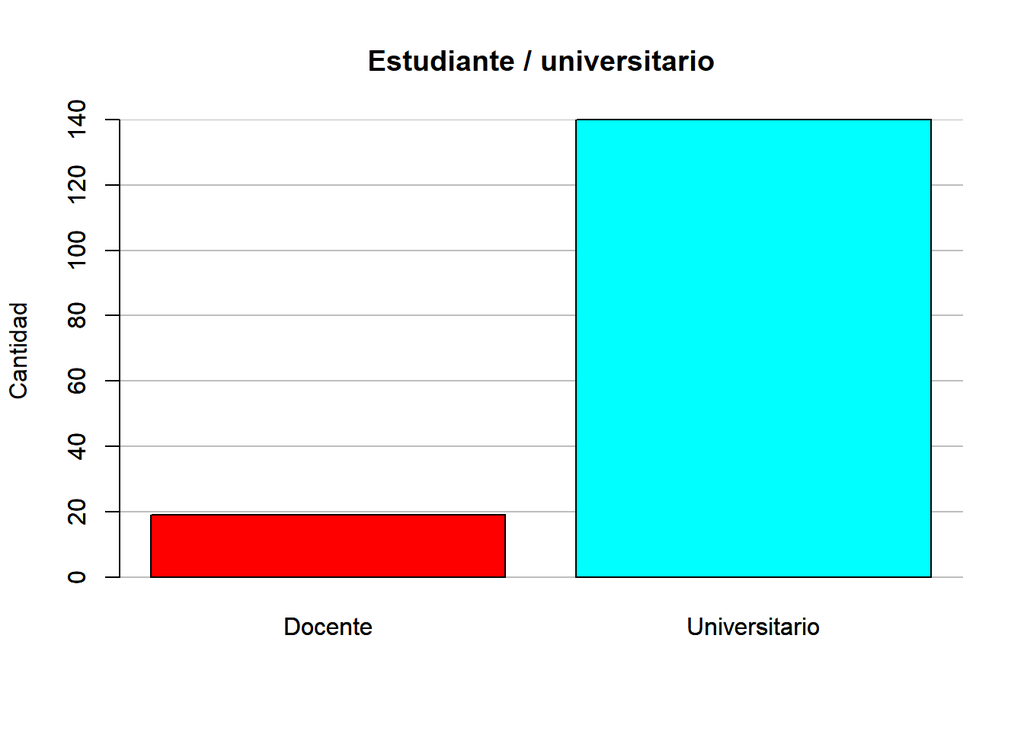

```r
barplot(table(DFV$Soy), col=rainbow(9), main = "Estudiante / universitario", ylab = "Cantidad")
grid(nx = NA, ny = NULL, lwd = 1, lty = 1, col = "gray")
barplot(table(DFV$Soy), col = rainbow(2), ylim = c(0, 15), add = TRUE)
```

*7.13.3. Análisis del gráfico:*

En la gráfica de barras “Estudiante / Universitario” se puede observar que la gran mayoría de encuestados para nuestra muestra estadística son los estudiantes universitarios.

*7.13.4. Hipótesis 13:*

## Tercera parte

#### **8.Pruebas de hipótesis**

Daremos inicio a la realización de las pruebas de hipótesis, priorizando aquellas pruebas de hipótesis con mayor impacto potencial en el estudio.

**8.1. Primera prueba:**

**8.1.1. Descriptor numérico**

```r
temp1 <- DFV[!is.na(DFV$`Universidad`), ]
temp2 <- DFV[!is.na(DFV$`Universidad_enseñanza`), ]
uni_estudia <- temp1$`Universidad`
uni_ensena <- temp2$`Universidad_enseñanza`
table(uni_estudia)
```

```
## uni_estudia
## Otros  PUCP    UL   UNI UNMSM    UP   UPC  UPCH  UTEC   UTP
##    16     2     9     1     2     7     5     2    88     8
```

```r
table(uni_ensena)
```

```
## uni_ensena
##  PUCP    UL   UNI UNMSM    UP  UPCH  USIL  UTEC
##     1     4     1     1     4     1     1     6
```

```r
cat("Moda de los estudiantes encuestados: ", mode(uni_estudia), "\n")
```

```
## Moda de los estudiantes encuestados:  UTEC
```

```r
cat("Moda de los docentes encuestados: ", mode(uni_ensena), "\n")
```

```
## Moda de los docentes encuestados:  UTEC
```

**8.1.2. Descriptor gráfico**

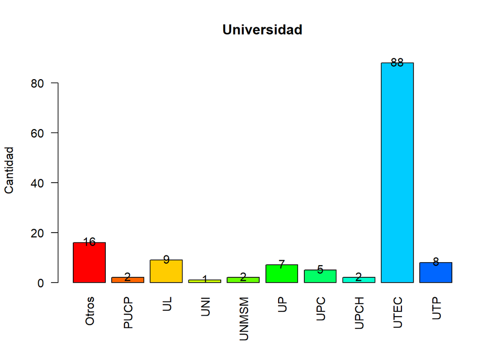

```r
A <-barplot(table(DFV$Universidad), col=rainbow(15), main = "Universidad", ylab = "Cantidad", ylim=c(0,90), las=2)
text(A, table(DFV$Universidad) + 0.5, labels = table(DFV$Universidad))
```

La hipótesis a contrastar es:

Ho: La cantidad de estudiantes encuestados que se concentran en UTEC no son más del 50%.

$$\pi\leq0.5$$
H1: La cantidad de estudiantes encuestados que se concentran en UTEC es mayor que 50%.

$$\pi>0.5$$
El estadístico de prueba a calcular es:

$$Z= \frac{\overline{p} -
p}{\sqrt{\frac{p(1-p)}{n}}}$$

El cálculo se realiza como:

```r
x=88
n=140
p <- 0.5  #J) Ver valor numérico en las hipótesis
pbarra <- x/n
ES <- sqrt(p*(1-p)/n)  #K) Error estándar (= desviación estándar del estadístico)
Z <- (pbarra - p)/ES    #L) Valor de prueba
Z
```

```
## [1] 3.042555
```

El Valor crítico de la prueba es:

```r
alfa <- 0.05
Critico <- qnorm(1-alfa)      #M) Valor crítico
Critico
```

```
## [1] 1.644854
```

El cálculo del valor se da mediante:

```r
1-pnorm(Z)
```

```
## [1] 0.001172893
```

Como la prueba resulta significativa, porque el p-valor es menor al nivel de significancia, se rechaza la hipótesis nula (Ho). De esta manera, la proporción de estudiantes encuestados son de UTEC, es decir, la muestra está desbalanceada a favor de dicha universidad.

**8.2. Segunda prueba de hipótesis:**

*8.2.1. Descriptor gráfico*

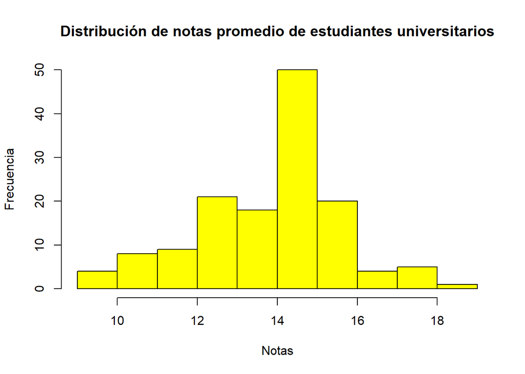

```r
hist(DFV$Promedio_academico,col="yellow", main="Distribución de notas promedio de estudiantes universitarios",xlab="Notas", ylab="Frecuencia")
```

**8.2.2. Hipótesis planteada:**

La nota promedio de los estudiantes es mayor a 13. Esto es un valor referencial, puesto que en muchas instituciones de calidad se exige a los alumnos que aprueban con 13.

```r
t.test(DFV$Promedio_academico,mu=13,alternative="greater")
```

```
##
##  One Sample t-test
##
## data:  DFV$Promedio_academico
## t = 8.4444, df = 139, p-value = 1.815e-14
## alternative hypothesis: true mean is greater than 13
## 95 percent confidence interval:
##  14.0623     Inf
## sample estimates:
## mean of x
##  14.32143
```

La prueba de hipótesis estadística es: Ho: El promedio de los estudiantes sea menor o igual a 13

$$\mu_{UTEC} \leq 13$$

H1: El promedio de los estudiantes sea mayor a 13
$$\mu_{UTEC} > 13$$

La prueba resulta significativa, pues, el p-valor es menor al nivel de significancia (0.05). Por lo tanto, se rechaza la hipótesis nula, es decir, los estudiantes universitarios presentan en promedio una nota superior a 13.

**8.3. Tercera prueba de hipótesis:**

*8.3.1. Descriptor gráfico*

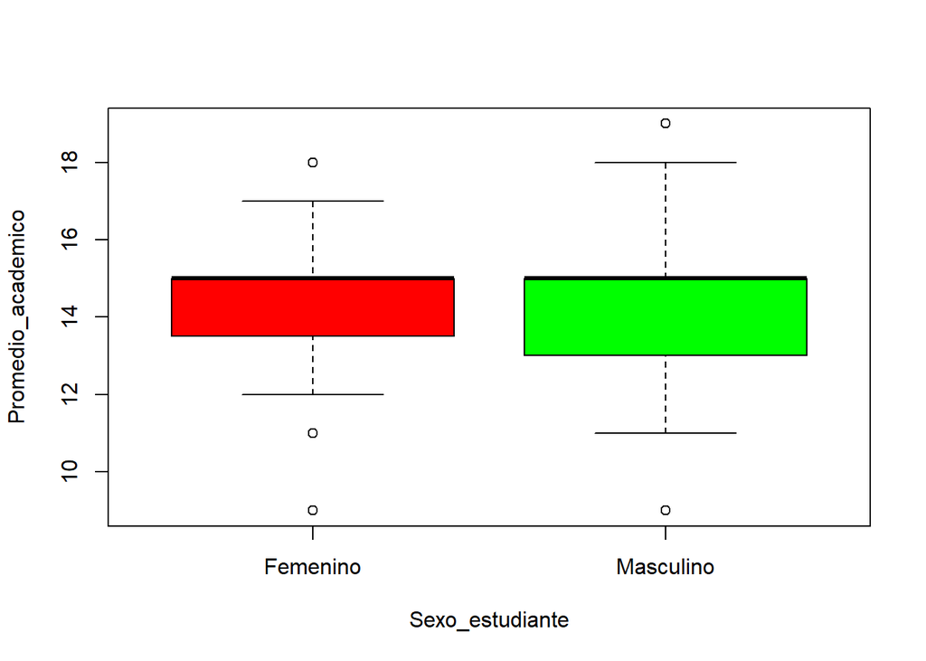

```r
boxplot(DFV$Promedio_academico[DFV$Universidad=="UTEC"]~
          DFV$Sexo_estudiante[DFV$Universidad=="UTEC"], xlab="Sexo_estudiante", ylab="Promedio_academico", col=rainbow(ncol(trees)))
```

El gráfico de cajas muestra un valor similar en las notas promedio entre varones y mujeres.

**8.3.2. Hipótesis planteada:**

El desempeño académico de los varones es similar al de las mujeres. Mediante esta hipótesis se demostrará la igualdad de habilidades intelectuales según género.

```r
t.test(DFV$Promedio_academico[DFV$Universidad=="UTEC"]~
          DFV$Sexo_estudiante[DFV$Universidad=="UTEC"])
```

```
##
##  Welch Two Sample t-test
##
## data:  DFV$Promedio_academico[DFV$Universidad == "UTEC"] by DFV$Sexo_estudiante[DFV$Universidad == "UTEC"]
## t = -0.05338, df = 84.177, p-value = 0.9576
## alternative hypothesis: true difference in means between group Femenino and group Masculino is not equal to 0
## 95 percent confidence interval:
##  -0.8693859  0.8239313
## sample estimates:
##  mean in group Femenino mean in group Masculino
##                14.25000                14.27273
```

La prueba de hipótesis correspondiente es:

Ho: La diferencia en el promedio de los estudiantes entre varón o mujer es igual a cero
$$\mu_{hombres} =
\mu_{mujeres}$$

H1: La diferencia en el promedio de los estudiantes entre varón o mujer no es igual a cero
$$\mu_{hombres} \neq
\mu_{mujeres}$$

**8.4. Cuarta prueba de hipótesis:**

*8.4.1. Descriptor gráfico*

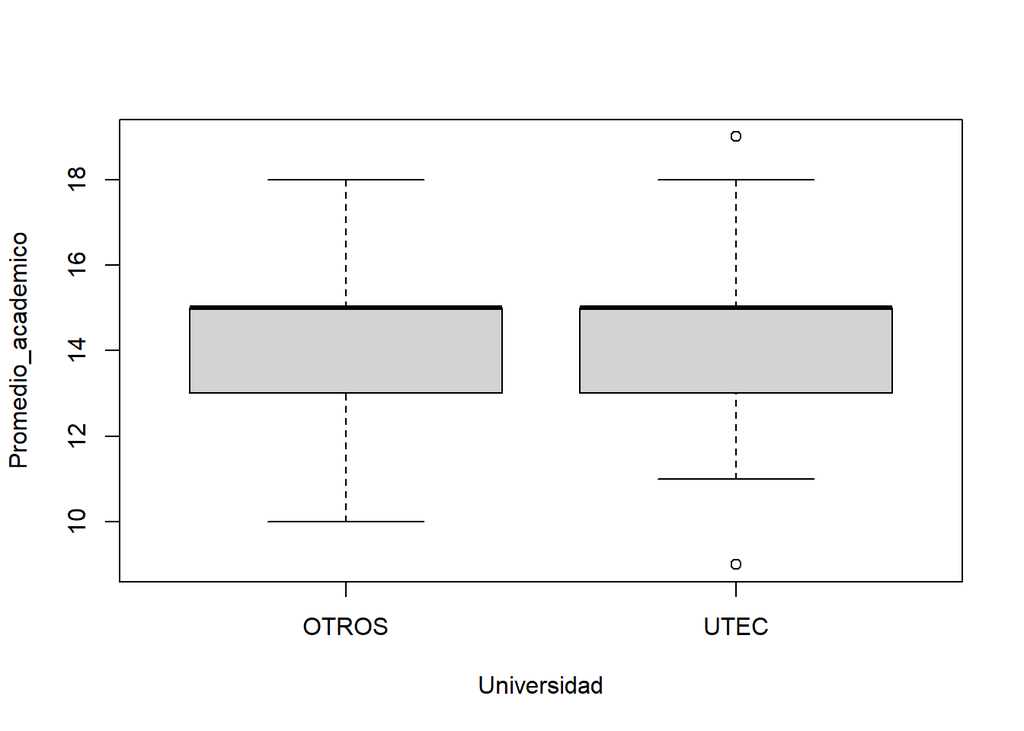

```r
univ=ifelse(DFV$Universidad=="UTEC","UTEC","OTROS")
boxplot(DFV$Promedio_academico~univ, xlab="Universidad", ylab="Promedio_academico")
```

El gráfico de cajas muestra un valor mediano similar en ambos grupos al considerar el 50% de las notas promedio centrales de los estudiantes.

**8.4.2. La hipótesis planteada es:** Los estudiantes de UTEC presentan un mayor rendimiento académico que el resto de las universidades.

La prueba de hipótesis correspondiente es:

Ho: El promedio acádemico de los estudiantes de UTEC es menor o igual al de otras universidades
$$\mu_{UTEC} \leq
\mu_{OTROS}$$
H1: El promedio acádemico de los estudiantes de UTEC es mayor al de otras universidades
$$\mu_{UTEC} > \mu_{OTROS}$$
Los alumnos de UTEC presentan mayor nota promedio que el resto de las universidades

```r
t.test(DFV$Promedio_academico~univ)
```

```
##
##  Welch Two Sample t-test
##
## data:  DFV$Promedio_academico by univ
## t = 0.52512, df = 124.64, p-value = 0.6004
## alternative hypothesis: true difference in means between group OTROS and group UTEC is not equal to 0
## 95 percent confidence interval:
##  -0.4477803  0.7712069
## sample estimates:
## mean in group OTROS  mean in group UTEC
##            14.42308            14.26136
```

La prueba resulta no significativa, pues, el p-valor de 0.6 es mayor al nivel de significancia. De esta manera, no se rechaza la hipótesis nula, es decir, la nota promedio de los estudiantes de UTEC no es superior al resto de universidades.

#### **9.Patrones**

Ahora bien, en este apartado estudiaremos desde el punto de vista de regresión al menos tres pares de variables numéricas relevantes de nuestro estudio con alguna relación aparente. Los que a su vez serán acompañados por gráficas relevantes y el análisis pertinente de residuos y coeficientes.

**Patrón 9.1**

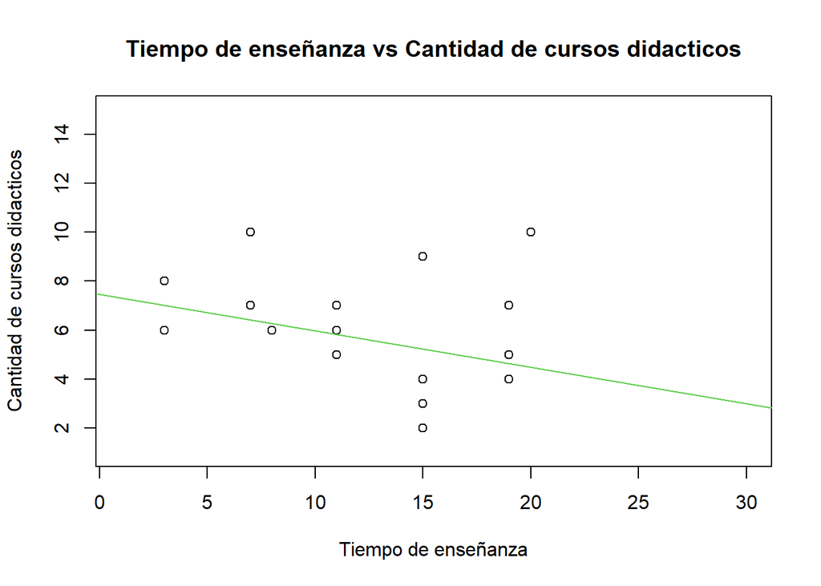

```r
plot(DFV$Tiempo_enseñanza,DFV$Cantidad_cursos_didacticos, main = "Tiempo de enseñanza vs Cantidad de cursos didacticos",xlab = "Tiempo de enseñanza",ylab = "Cantidad de cursos didacticos", xlim=c(1,30), ylim=c(1,15))
abline(lm(DFV$Cantidad_cursos_didacticos~DFV$Tiempo_enseñanza), col=3)  # regresión line)
```

El gráfico de dispersión muestra un patrón de tendencia negativo, es decir, a medida que un docente lleva más años como docente la cantidad de cursos didácticos que lleva disminuye.

```r
m1=lm(Tiempo_enseñanza~Cantidad_cursos_didacticos,data=DFV)
summary(m1)
```

```
##
## Call:
## lm(formula = Tiempo_enseñanza ~ Cantidad_cursos_didacticos, data = DFV)
##
## Residuals:
##     Min      1Q  Median      3Q     Max
## -9.7258 -2.8574 -0.0414  4.5637  9.5898
##
## Coefficients:
##                            Estimate Std. Error t value Pr(>|t|)
## (Intercept)                 16.1992     2.8107   5.763 2.29e-05 ***
## Cantidad_cursos_didacticos  -0.5789     0.4582  -1.263    0.223
## ---
## Signif. codes:  0 '***' 0.001 '**' 0.01 '*' 0.05 '.' 0.1 ' ' 1
##
## Residual standard error: 5.318 on 17 degrees of freedom
##   (140 observations deleted due to missingness)
## Multiple R-squared:  0.08585,    Adjusted R-squared:  0.03207
## F-statistic: 1.596 on 1 and 17 DF,  p-value: 0.2235
```

*9.1.1. Patrón planteado :*

Los docentes universitarios presentan dificultades en capacitación pedagógica. Esta hipótesis surge por la necesidad de cuantificar de alguna forma si los estudiantes reciben una buena educación. Parte de ello, implica conocer la formación pedagógica de los docentes conociendo su tiempo enseñando las diferentes materias

La prueba de hipótesis a contrastar es:

$$H_{0}:\beta_1=0$$

$$H_{1}:\beta_1 \neq 0$$

El valor de la pendiente es $\beta_{1}=-0.5789$ resulta no significativa porque el **Pr(>|t|)** de la misma es mayor al nivel de significancia por lo que la hipótesis nula (Ho) no se rechaza teniendo que $\beta_{1}=0$, es decir, el tiempo docente no influye en la cantidad de cursos didácticos.

*9.1.2. Verificación de supuestos*

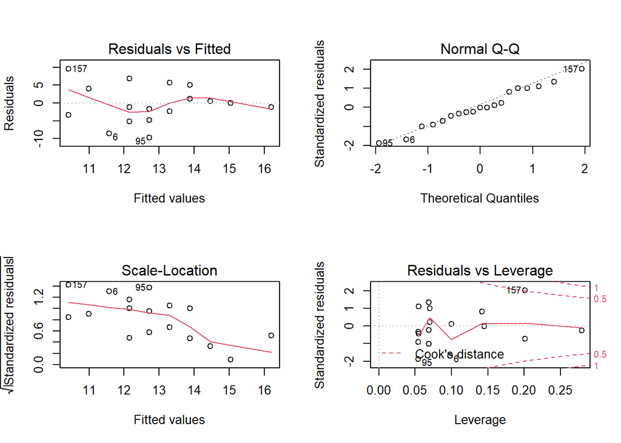

```r
par(mfrow=c(2,2))
plot(m1)
```

El gráfico de residuales VS valores predichos y el gráfico de raíz de residuales estandarizados VS valores predichos se emplean para identificar problemas de heterocedasticidad. En ambos gráficos, se observa patrones de inconsistencia del modelo. Esto sugiere pensar que no se cumple el supuesto de homocedasticidad.

El gráfico QQ se observa que existe una gran cantidad de observaciones que se ajustan a la linea diagonal, es decir, los residuales se ajustarían a la distribución Normal.

Las pruebas de hipótesis

*9.1.3. Normalidad de residuales*

H0: Los residuales se ajustan a la distribución Normal

H1: Los residuales NO se ajustan a la distribución Normal

```r
r=rstandard(m1)
shapiro.test(r)
```

```
##
##  Shapiro-Wilk normality test
##
## data:  r
## W = 0.97825, p-value = 0.9202
```

*9.1.4. Varianza contante de los residuales*

H0: Los residuales presentan varianza constante

H1: Los residuales NO presentan varianza constante

```r
library(car)
ncvTest(m1)
```

```
## Non-constant Variance Score Test
## Variance formula: ~ fitted.values
## Chisquare = 3.324991, Df = 1, p = 0.068234
```

La prueba resulta NO significativa, (p-valor > 0.05), es decir, los residuales presentan varianza constante

*9.1.5. Independencia de los residuales*

H0: Los residuales son independientes

H1: Los residuales NO son independientes

```r
durbinWatsonTest(m1)
```

```
##  lag Autocorrelation D-W Statistic p-value
##    1       0.3424317      1.120889   0.014
##  Alternative hypothesis: rho != 0
```

**Patrón 9.2**

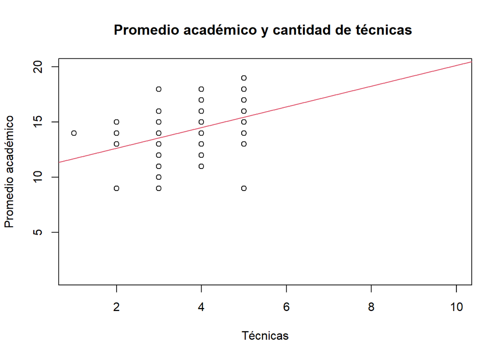

```r
plot(DFV$Cantidad_tecnicas,DFV$Promedio_academico, main = "Promedio académico y cantidad de técnicas ",xlab = "Técnicas",ylab = "Promedio académico", xlim=c(1,10), ylim=c(1,20))
abline(lm(DFV$Promedio_academico~DFV$Cantidad_tecnicas), col=2)  # regresión line
```

```r
table(DFV[DFV$Soy == "Universitario",]$Cantidad_tecnicas,DFV[DFV$Soy == "Universitario",]$Promedio_academico)
```

```
##
##      9 10 11 12 13 14 15 16 17 18 19
##   1  0  0  0  0  0  1  0  0  0  0  0
##   2  1  0  0  0  1  1  1  0  0  0  0
##   3  1  1  6  7  3  6 13  4  0  1  0
##   4  0  0  2  2 15  9 32  6  1  1  0
##   5  1  0  0  0  2  1  4 10  3  3  1
```

*9.2.1. Patrón planteada :*

```r
m2=lm(Promedio_academico~Cantidad_tecnicas,data=DFV)
summary(m2)
```

```
##
## Call:
## lm(formula = Promedio_academico ~ Cantidad_tecnicas, data = DFV)
##
## Residuals:
##     Min      1Q  Median      3Q     Max
## -6.4464 -1.5089  0.4911  1.3817  4.4286
##
## Coefficients:
##                   Estimate Std. Error t value Pr(>|t|)
## (Intercept)        10.7589     0.7113  15.127  < 2e-16 ***
## Cantidad_tecnicas   0.9375     0.1833   5.115 1.03e-06 ***
## ---
## Signif. codes:  0 '***' 0.001 '**' 0.01 '*' 0.05 '.' 0.1 ' ' 1
##
## Residual standard error: 1.704 on 138 degrees of freedom
##   (19 observations deleted due to missingness)
## Multiple R-squared:  0.1594, Adjusted R-squared:  0.1533
## F-statistic: 26.16 on 1 and 138 DF,  p-value: 1.031e-06
```

La prueba de hipótesis a contrastar es:

$$H_{0}:\beta_1=0$$

$$H_{1}:\beta_1 \neq 0$$

El valor de la pendiente $\beta_{1}=0.9375$ resulta significativa, porque el **Pr(>|t|)** de la misma es menor al nivel de significancia por lo que la hipótesis se rechaza teniendo que $\beta_1 \neq 0$, es decir, la cantidad de técnicas empleadas influye en el promedio de los estudiantes. El modelo de regresión lineal simple presenta un $R^{2}=0.1594$, es decir, la variable la cantidad de técnicas empleadas explica, el 15.94% de la variabilidad del promedio de las calificaciones de los estudiantes. Este valor bajo no indica que las variables no se relacionen, sino que existe otras variables que explican a la variable respuesta.

*9.2.2. Verificación de supuestos*

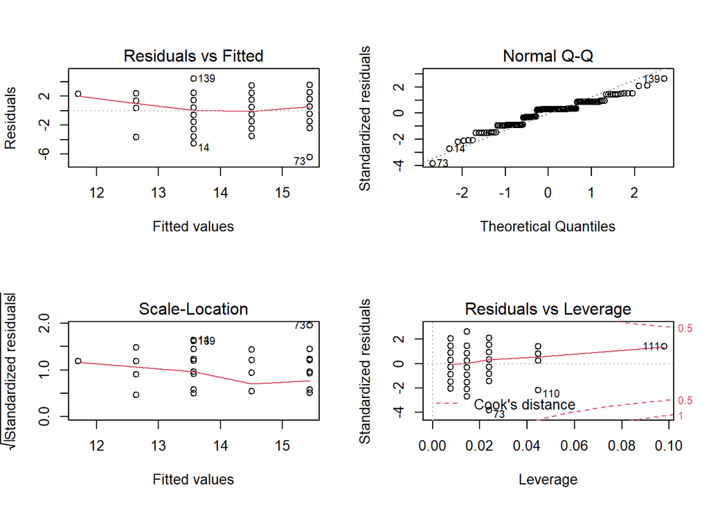

```r
par(mfrow=c(2,2))
plot(m2)
```

El gráfico QQ se observa que existe una gran cantidad de observaciones que no se ajustan a la linea diagonal, es decir, los residuales no se ajustarían a la distribución Normal.

Por último, el gráfico de residuales VS Leverage señala las observaciones 73, 110 y 111.

Las pruebas de hipótesis

*9.2.3. Normalidad de residuales*

H0: Los residuales se ajustan a la distribución Normal

H1: Los residuales NO se ajustan a la distribución Normal

```r
r=rstandard(m2)
shapiro.test(r)
```

```
##
##  Shapiro-Wilk normality test
##
## data:  r
## W = 0.94841, p-value = 4.519e-05
```

La prueba resulta significativa, (p-valor < 0.05), es decir, los residuales NO se ajustan a la distribución Normal.

*8.2.4. Varianza contante de los residuales*

H0: Los residuales presentan varianza constante

H1: Los residuales NO presentan varianza constante

```r
library(car)
ncvTest(m2)
```

```
## Non-constant Variance Score Test
## Variance formula: ~ fitted.values
## Chisquare = 1.183782, Df = 1, p = 0.27659
```

La prueba resulta NO significativa, (p-valor > 0.05), es decir, los residuales presentan varianza constante

*9.2.5. Independencia de los residuales*

H0: Los residuales son independientes

H1: Los residuales NO son independientes

```r
durbinWatsonTest(m2)
```

```
##  lag Autocorrelation D-W Statistic p-value
##    1       0.1732633      1.617366   0.028
##  Alternative hypothesis: rho != 0
```

**Patrón 9.3**

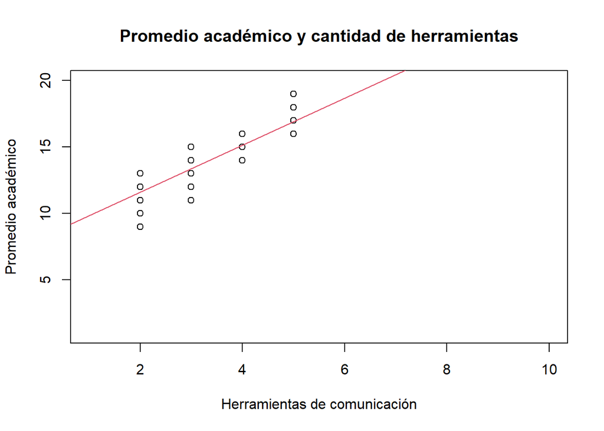

```r
plot(DFV$Cantidad_herramientas,DFV$Promedio_academico, main = "Promedio académico y cantidad de herramientas",xlab = "Herramientas de comunicación",ylab = "Promedio académico", xlim=c(1,10), ylim=c(1,20))
abline(lm(DFV$Promedio_academico~DFV$Cantidad_herramientas), col=2)  # regresión line
```

```r
table(DFV[DFV$Soy == "Universitario",]$Cantidad_herramientas,DFV[DFV$Soy == "Universitario",]$Promedio_academico)
```

```
##
##      9 10 11 12 13 14 15 16 17 18 19
##   2  3  1  7  3  1  0  0  0  0  0  0
##   3  0  0  1  6 20 13 18  0  0  0  0
##   4  0  0  0  0  0  5 32  8  0  0  0
##   5  0  0  0  0  0  0  0 12  4  5  1
```

*9.3.1. Patrón planteado:*

“La cantidad de herramientas empleadas en clase influyen en el promedio académico de los estudiantes universitarios”. En nuestra tercera hipótesis, se relaciona el promedio académico con la cantidad de herramientas de comunicación que tienen los estudiantes para mantenerse en contacto con sus profesores. Según la gráfica de dispersión, la pendiente de la regresión lineal es alta y es directa, lo que indica que por el momento, la relación entre ambas variables es fuerte y directamente proporcional. Los indicadores nos demuestran que a medida que los estudiantes tienen más maneras de comunicarse con sus maestros, su promedio académico es mayor.

```r
m3=lm(Promedio_academico~Cantidad_herramientas,data=DFV)
summary(m3)
```

```
##
## Call:
## lm(formula = Promedio_academico ~ Cantidad_herramientas, data = DFV)
##
## Residuals:
##     Min      1Q  Median      3Q     Max
## -2.6090 -0.4399 -0.1580  0.6165  2.0676
##
## Coefficients:
##                       Estimate Std. Error t value Pr(>|t|)
## (Intercept)            8.06009    0.34306   23.50   <2e-16 ***
## Cantidad_herramientas  1.77447    0.09432   18.81   <2e-16 ***
## ---
## Signif. codes:  0 '***' 0.001 '**' 0.01 '*' 0.05 '.' 0.1 ' ' 1
##
## Residual standard error: 0.9842 on 138 degrees of freedom
##   (19 observations deleted due to missingness)
## Multiple R-squared:  0.7195, Adjusted R-squared:  0.7174
## F-statistic: 353.9 on 1 and 138 DF,  p-value: < 2.2e-16
```

La prueba de hipótesis a contrastar es:

$$H_{0}:\beta_1=0$$

$$H_{1}:\beta_1 \neq0$$

El valor de la pendiente $\beta_{1}=1.77$ resulta significativa, porque el **Pr(>|t|)** de la misma es menor al nivel de significancia por lo que la hipótesis nula se rechaza teniendo que $\beta_1 \neq0$, es decir, la cantidad de herramientas empleadas en clase influye en el promedio de los estudiantes.

El modelo de regresión lineal simple presenta un $R^{2}=0.7195$, es decir, la variable la cantidad de herramientas empleadas en clase, el 71.954% de la variabilidad del promedio de las calificaciones de los estudiantes. Este valor es regularmente alto, lo cual indica un efecto importante en el estudio.

*9.3.2. Verificación de supuestos*

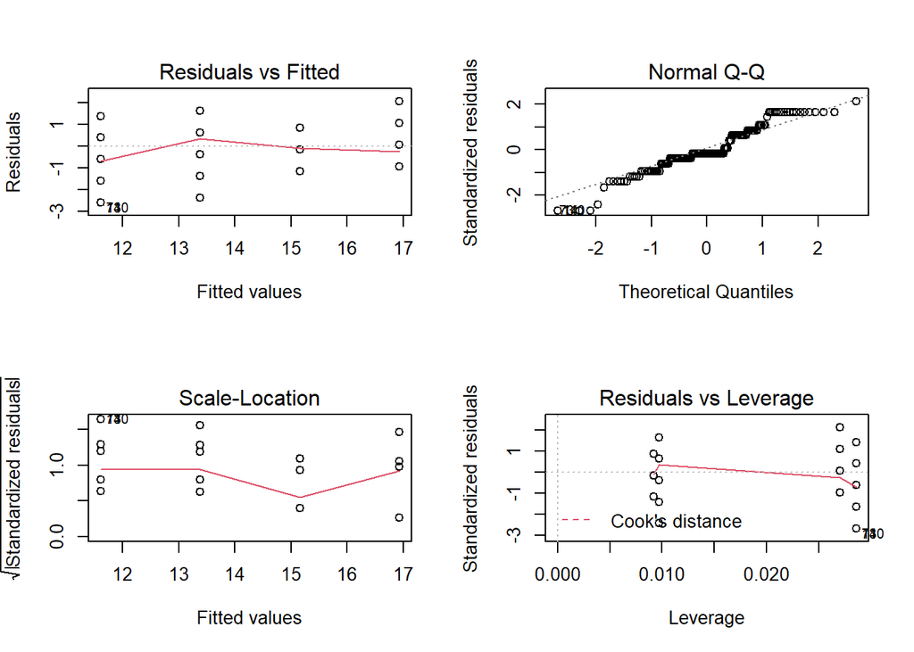

```r
par(mfrow=c(2,2))
plot(m3)
```

El gráfico QQ se observa que existe una gran cantidad de observaciones que no se ajustan a la linea diagonal, es decir, los residuales no se ajustarían a la distribución Normal.

Por último el gráfico de residuales VS Leverage señala las observaciones 73 y 110.

Las pruebas de hipótesis

*9.3.3. Normalidad de residuales*

H0: Los residuales se ajustan a la distribución Normal

H1: Los residuales NO se ajustan a la distribución Normal

```r
r=rstandard(m3)
shapiro.test(r)
```

```
##
##  Shapiro-Wilk normality test
##
## data:  r
## W = 0.94988, p-value = 5.908e-05
```

La prueba resulta significativa, (p-valor < 0.05), es decir, los residuales NO se ajustan a la distribución Normal.

*9.3.4. Varianza contante de los residuales*

H0: Los residuales presentan varianza constante

H1: Los residuales NO presentan varianza constante

```r
ncvTest(m3)
```

```
## Non-constant Variance Score Test
## Variance formula: ~ fitted.values
## Chisquare = 10.03408, Df = 1, p = 0.0015367
```

La prueba resulta significativa, (p-valor < 0.05), es decir, los residuales NO presentan varianza constante

*9.3.5. Independencia de los residuales*

H0: Los residuales son independientes H1: Los residuales NO son independientes

```r
durbinWatsonTest(m3)
```

```
##  lag Autocorrelation D-W Statistic p-value
##    1       0.2261512      1.538072    0.01
##  Alternative hypothesis: rho != 0
```

La prueba resulta significativa, (p-valor < 0.05), es decir, los residuales NO son independientes.

**Patrón 9.4**

La cantidad de dispositivos tecnológicos que tiene un estudiante no influye en el promedio académico que este posee.

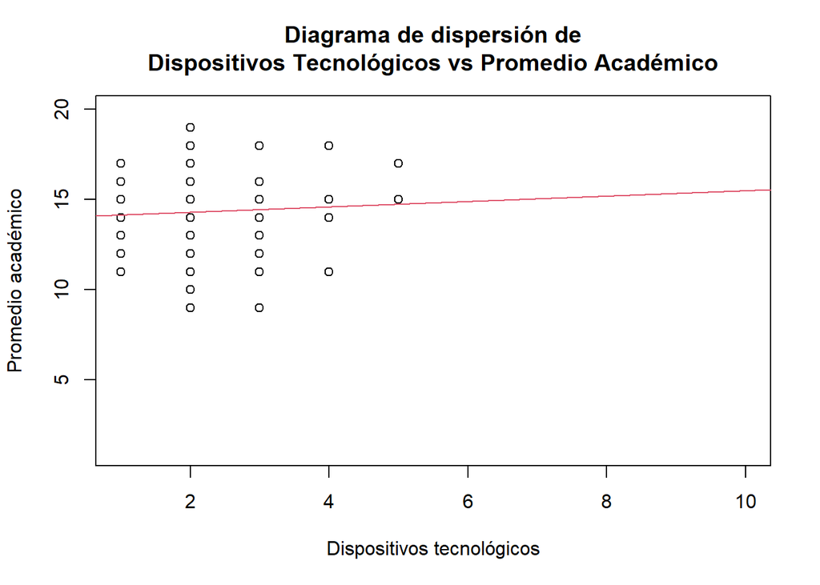

```r
plot(DFV$Dispositivos_tecnologicos,DFV$Promedio_academico, main = "Diagrama de dispersión de
Dispositivos Tecnológicos vs Promedio Académico",xlab = "Dispositivos tecnológicos",ylab = "Promedio académico", xlim=c(1,10), ylim=c(1,20))
abline(lm(DFV$Promedio_academico~DFV$Dispositivos_tecnologicos), col=2)  # regresión line
```

```r
table(DFV[DFV$Soy == "Universitario",]$Dispositivos_tecnologicos,DFV[DFV$Soy == "Universitario",]$Promedio_academico)
```

```
##
##      9 10 11 12 13 14 15 16 17 18 19
##   1  0  0  1  1  2  2  9  2  1  0  0
##   2  1  1  4  6 16 13 31 14  2  1  1
##   3  2  0  2  2  3  1  7  4  0  1  0
##   4  0  0  1  0  0  2  2  0  0  3  0
##   5  0  0  0  0  0  0  1  0  1  0  0
```

```r
m4=lm(Promedio_academico~Dispositivos_tecnologicos,data=DFV)
summary(m4)
```

```
##
## Call:
## lm(formula = Promedio_academico ~ Dispositivos_tecnologicos,
##     data = DFV)
##
## Residuals:
##     Min      1Q  Median      3Q     Max
## -5.4423 -1.2939  0.6319  0.8546  4.7061
##
## Coefficients:
##                           Estimate Std. Error t value Pr(>|t|)
## (Intercept)                13.9970     0.4664  30.013   <2e-16 ***
## Dispositivos_tecnologicos   0.1484     0.2010   0.739    0.461
## ---
## Signif. codes:  0 '***' 0.001 '**' 0.01 '*' 0.05 '.' 0.1 ' ' 1
##
## Residual standard error: 1.855 on 138 degrees of freedom
##   (19 observations deleted due to missingness)
## Multiple R-squared:  0.003938,   Adjusted R-squared:  -0.00328
## F-statistic: 0.5456 on 1 and 138 DF,  p-value: 0.4614
```

La prueba de hipótesis a contrastar es:

$$H_{0}:\beta_1=0$$

$$H_{1}:\beta_1 \neq0$$

El valor de la pendiente $\beta_{1}=0.1484$ resulta NO significativa, porque el **Pr(>|t|)** de la misma es mayor al nivel de significancia por lo que la hipótesis nula no se rechaza teniendo que $\beta_{1}=0$, es decir, la cantidad de dispositivos tecnológicos NO influye en el promedio de los estudiantes.

*9.4.1. Verificación de supuestos*

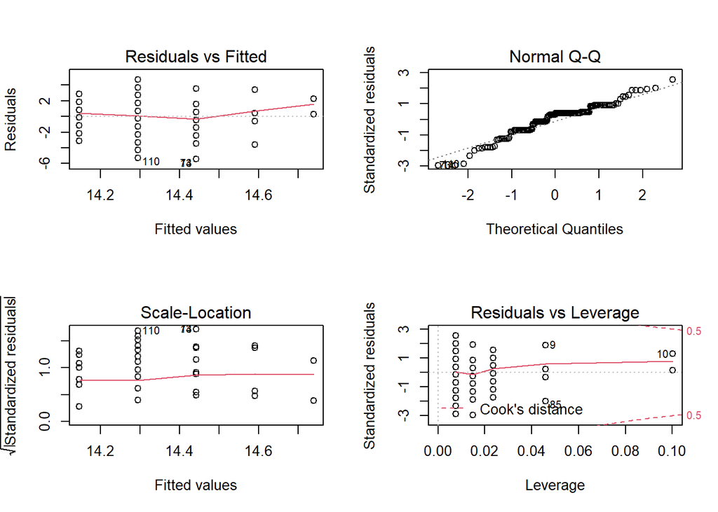

```r
par(mfrow=c(2,2))
plot(m4)
```

El gráfico QQ se observa que existe una gran cantidad de observaciones que no se ajustan a la linea diagonal, es decir, los residuales no se ajustarían a la distribución Normal.

Por último el gráfico de residuales VS Leverage señala las observaciones 9, 85 y 10.

Las pruebas de hipótesis

*9.4.2. Normalidad de residuales*

H0: Los residuales se ajustan a la distribución Normal

H1: Los residuales NO se ajustan a la distribución Normal

```r
r=rstandard(m4)
shapiro.test(r)
```

```
##
##  Shapiro-Wilk normality test
##
## data:  r
## W = 0.9503, p-value = 6.382e-05
```

La prueba resulta significativa, (p-valor < 0.05), es decir, los residuales NO se ajustan a la distribución Normal.

*9.4.3. Varianza contante de los residuales*

H0: Los residuales presentan varianza constante

H1: Los residuales NO presentan varianza constante

```r
library(car)
ncvTest(m4)
```

```
## Non-constant Variance Score Test
## Variance formula: ~ fitted.values
## Chisquare = 6.412809, Df = 1, p = 0.01133
```

*9.4.4. Independencia de los residuales*

H0: Los residuales son independientes

H1: Los residuales NO son independientes

```r
durbinWatsonTest(m4)
```

```
##  lag Autocorrelation D-W Statistic p-value
##    1       0.1852385       1.59933   0.024
##  Alternative hypothesis: rho != 0
```